# Targeting A Housing Subsidy

By Stephanie Onuaja

November 16, 2022

## 0.1 Motivation

The Department of Housing and Community Development (HCD) in Emil City has a program that targets homeowners who qualify for a home repair tax credit. It has been around for 20 years with severely low rates of uptake from homeowners. They contact eligible homeowners each year, but not all eligible homeowners who enter the program take the credit. HCD allocates $2,850 in marketing per homeowner and the tax credit amounts to $5,000 per homeowner. Through program evaluation, researchers found that houses that transacted after taking the credit sold with a $10,000 premium. Additionally, homes surrounding the repaired home see an aggregate premium of $56,000, on average. To ensure homeowners in Emil City benefit from the home repair tax credit, I developed a decision-making tool to improve the outcome of homeowners receiving the tax credit. The goal is to convert the client-level data from previous campaigns into a decision-making analytic that would produce a more targeted campaign while reducing outreach costs.

## 0.2 Exploratory Analysis

### 0.2.1 Continuous Features

Starting with the continuous variables, the plots below group the continuous features by “yes” – meaning individuals that entered the program, and “no” – individuals that did not enter the program.

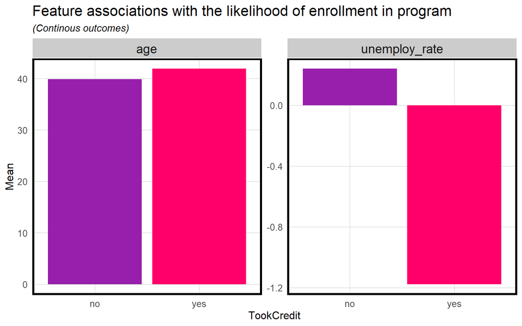

```r
Housing %>%
  dplyr::select(y, unemploy_rate, age) %>%
  gather(Variable, value, -y) %>%
  ggplot(aes(y, value, fill=y)) +
    geom_bar(position = "dodge", stat = "summary", fun = "mean") +
    facet_wrap(~Variable, scales = "free") +
    scale_fill_manual(values = palette2) +
    labs(x="TookCredit", y="Mean",
         title = "Feature associations with the likelihood of enrollment in program",
         subtitle = "(Continous outcomes)") +
    plotTheme() + theme(legend.position = "none")
```

For age, it is a bit unclear how much more older homeowners tend to enroll in the program. On the other hand, more homeowners tend to enroll in the program when the unemployment rates were lower.

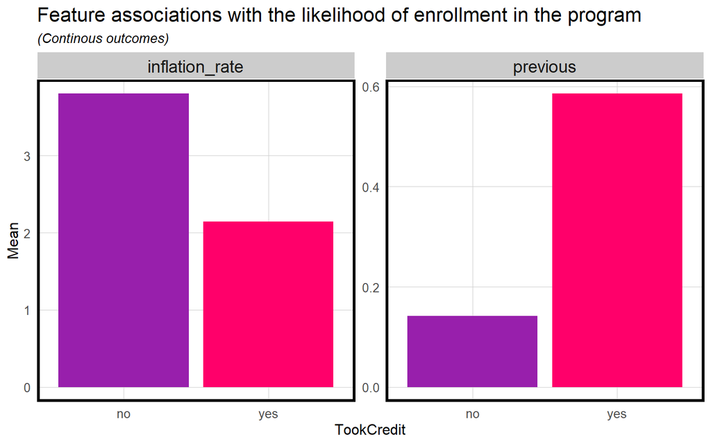

```r
Housing %>%
  dplyr::select(y, inflation_rate, previous) %>%
  gather(Variable, value, -y) %>%
  ggplot(aes(y, value, fill=y)) +
    geom_bar(position = "dodge", stat = "summary", fun = "mean") +
    facet_wrap(~Variable, scales = "free") +
    scale_fill_manual(values = palette2) +
    labs(x="TookCredit", y="Mean",
         title = "Feature associations with the likelihood of enrollment in the program",
         subtitle = "(Continous outcomes)") +
    plotTheme() + theme(legend.position = "none")
```

Higher inflation rates decrease the likelihood of a homeowner enrolling in the program. The more times homeowners are contacted before a campaign increases the likelihood of them enrolling in the program.

### 0.2.2 Two category features (Yes/No)

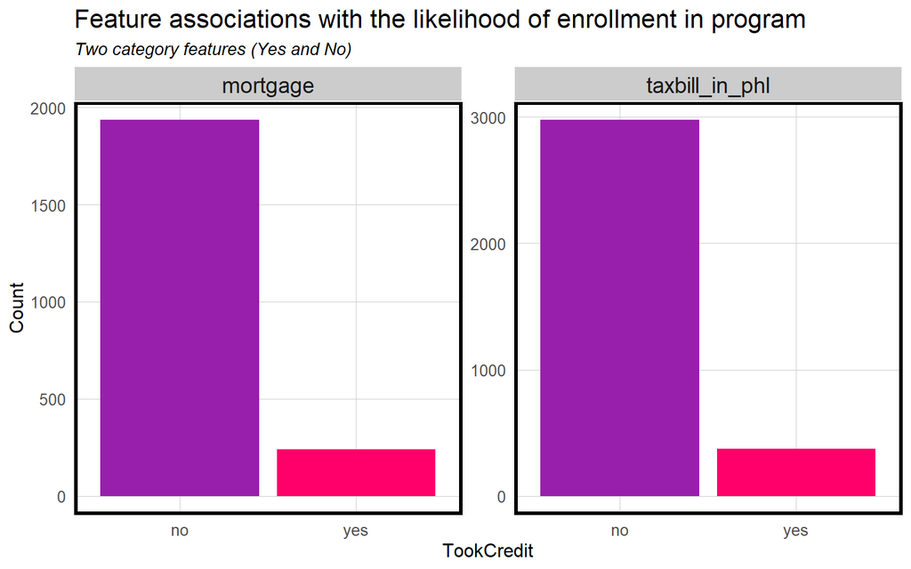

```r
Housing %>%
  dplyr::select(y, mortgage, taxbill_in_phl) %>%
  gather(Variable, value, -y) %>%
  count(Variable, value, y) %>%
  filter(value == "yes") %>%
    ggplot(aes(y, n, fill = y)) +
      geom_bar(position = "dodge", stat="identity") +
      facet_wrap(~Variable, scales = "free", ncol=4) +
      scale_fill_manual(values = palette2) +
      labs(x="TookCredit", y="Count",
           title = "Feature associations with the likelihood of enrollment in program",
           subtitle = "Two category features (Yes and No)") +
      plotTheme() + theme(legend.position = "none")
```

More people that do not enroll in the program are owners with mortgages and full-time residents in Philadelphia. This shows that most homeowners do not enroll in this program.

### 0.2.3 Multiple category features

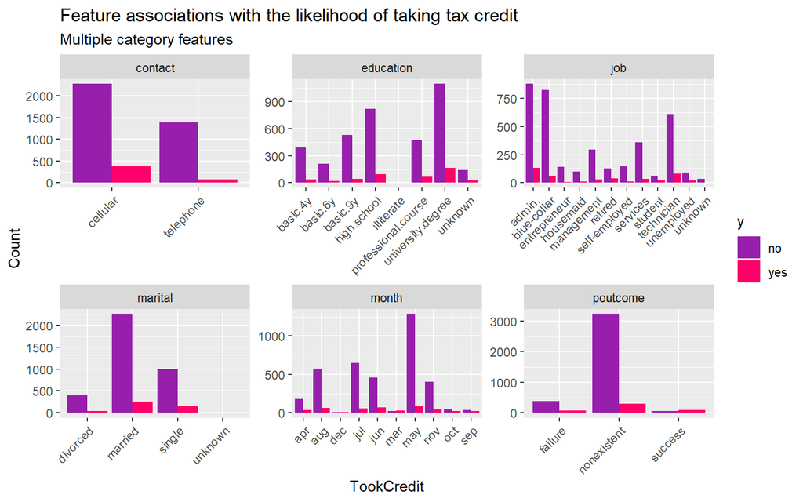

```r
Housing %>%
  dplyr::select(y, poutcome, marital, job, education, contact, month) %>%
  gather(Variable, value, -y) %>%
  count(Variable, value, y) %>%
  ggplot(aes(value, n, fill = y)) +
    geom_bar(position = "dodge", stat="identity") +
    facet_wrap(~Variable, scales="free") +
    scale_fill_manual(values = palette2) +
    labs(x="TookCredit", y="Count",
         title = "Feature associations with the likelihood of taking tax credit",
         subtitle = "Multiple category features") +
    theme(axis.text.x = element_text(angle=45, hjust=1))
```

The plots suggest that the most effective means of contact is through cellular. University degree holders are the most likely to enroll in the program. Married households are most likely to enroll in the program, and at the same time, they are the most likely not to enroll in the program compared to the other households. Where outcomes of the previous marketing campaign were non-existent, the likelihood of people not enrolling in the program was the highest.

## 0.3 Logistic Regression

### 0.3.1 Training / Test sets

The data was spit into a 65/35 training set/ test set.

```r
set.seed(3456)
trainIndex <- createDataPartition(Housing$y, p = .65,
                                  list = FALSE,
                                  times = 1)
yTrain <- Housing[ trainIndex,]
yTest  <- Housing[-trainIndex,]
```

### 0.3.2 Regression 1 - Kitchen sink model

```r
reg1 <- glm(y_numeric ~ .,
                  data=yTrain %>% dplyr::select(-y, -taxLien),
                  family="binomial" (link="logit"))
```

```
##
## Call:
## glm(formula = y_numeric ~ ., family = binomial(link = "logit"),
##     data = yTrain %>% dplyr::select(-y, -taxLien))
##
## Deviance Residuals:
##     Min       1Q   Median       3Q      Max
## -2.4041  -0.4153  -0.3403  -0.2745   2.7801
##
## Coefficients:
##                                  Estimate   Std. Error z value Pr(>|z|)
## (Intercept)                  -62.19586855 131.70394125  -0.472   0.6368
## X                              0.00005255   0.00006002   0.875   0.3813
## age                            0.00383747   0.00851456   0.451   0.6522
## jobblue-collar                -0.19395586   0.26978580  -0.719   0.4722
## jobentrepreneur               -0.42432097   0.45743139  -0.928   0.3536
## jobhousemaid                  -0.60256812   0.55248641  -1.091   0.2754
## jobmanagement                 -0.29769569   0.30609923  -0.973   0.3308
## jobretired                    -0.06939378   0.37067663  -0.187   0.8515
## jobself-employed              -0.72267757   0.45910449  -1.574   0.1155
## jobservices                   -0.38063019   0.29988752  -1.269   0.2044
## jobstudent                    -0.58636850   0.47512363  -1.234   0.2172
## jobtechnician                 -0.07096711   0.23348744  -0.304   0.7612
## jobunemployed                  0.01409981   0.42873890   0.033   0.9738
## jobunknown                    -0.31265365   0.70013747  -0.447   0.6552
## maritalmarried                -0.00337158   0.23887853  -0.014   0.9887
## maritalsingle                 -0.03590931   0.27433401  -0.131   0.8959
## maritalunknown               -11.78756359 329.19219037  -0.036   0.9714
## educationbasic.6y              0.37735844   0.40058469   0.942   0.3462
## educationbasic.9y             -0.06335464   0.33936436  -0.187   0.8519
## educationhigh.school           0.14771239   0.32365191   0.456   0.6481
## educationilliterate          -13.27033316 882.74356255  -0.015   0.9880
## educationprofessional.course   0.17986922   0.35080890   0.513   0.6081
## educationuniversity.degree     0.30199002   0.32392782   0.932   0.3512
## educationunknown               0.34675034   0.41419957   0.837   0.4025
## mortgageunknown               -0.12385996   0.56929048  -0.218   0.8278
## mortgageyes                   -0.20775344   0.14287048  -1.454   0.1459
## taxbill_in_phlyes              0.18175191   0.20074694   0.905   0.3653
## contacttelephone              -0.63330786   0.28513527  -2.221   0.0263 *
## monthaug                       0.02148474   0.44373694   0.048   0.9614
```

[output cut: 17 more lines]

```
## unemploy_rate                 -0.93563334   0.48646189  -1.923   0.0544 .
## cons.price.idx                 0.89783251   0.86200128   1.042   0.2976
## cons.conf.idx                  0.02113176   0.02936107   0.720   0.4717
## inflation_rate                 0.51062205   0.44835667   1.139   0.2548
## spent_on_repairs              -0.00477565   0.01074639  -0.444   0.6568
## ---
## Signif. codes:  0 '***' 0.001 '**' 0.01 '*' 0.05 '.' 0.1 ' ' 1
##
## (Dispersion parameter for binomial family taken to be 1)
##
##     Null deviance: 1853.7  on 2678  degrees of freedom
## Residual deviance: 1488.2  on 2628  degrees of freedom
## AIC: 1590.2
##
## Number of Fisher Scoring iterations: 13
```

```r
# Goddness of Fit
pR2(reg1)[4]
## fitting null model for pseudo-r2
## McFadden
## 0.197194
```

### 0.3.3 Feature Engineering

```r
# Education
Housing$edugroups <- sapply(Housing$education, switch,
                  basic.4y = 'lessthanHS',
                  basic.6y = 'lessthanHS',
                  basic.9y = 'lessthanHS',
                  high.school = 'HS',
                  illiterate = 'other',
                  university.degree = 'Higheredu',
                  professional.course = 'Higheredu',
                  unknown = 'other')

# Age Groups, 35 and below = Young adults, 35 to 65 = Middle-aged, above 65 = Old-aged
Housing <-
  mutate(Housing, agegroups = case_when(age <= 35 ~ "Young adults",
                                        age >=36 & age <= 65 ~ "Middle-aged",
                                        age >= 66 ~ "Old-aged"))

# Employment status
  Housing <-
  mutate(Housing, Employ = case_when(job == "student" | job == "unemployed" | job == "retired" ~ "unemployed",
                                   TRUE  ~ "employed"))

# Season
Housing <-
  Housing %>%
  mutate(Season = case_when(
    month == "dec" |month == "jan" | month == "feb" ~ "Winter",
    month == "mar" |month == "apr" | month == "may" ~ "Spring",
    month == "jun" |month == "jul" | month == "aug" ~ "Summer",
    month == "sep" |month == "oct" | month == "nov" ~ "Fall"))
```

### 0.3.4 Regression 2 - Engineered model

```r
set.seed(3456)
trainIndex <- createDataPartition(Housing$y, p = .65,
                                  list = FALSE,
                                  times = 1)
yTrain <- Housing[ trainIndex,]
yTest  <- Housing[-trainIndex,]

reg2 <- glm(y_numeric ~ .,
                  data=yTrain %>% dplyr::select(-y, -taxLien, -age, -month, -education, -job),
                  family="binomial" (link="logit"))
```

```
##
## Call:
## glm(formula = y_numeric ~ ., family = binomial(link = "logit"),
##     data = yTrain %>% dplyr::select(-y, -taxLien, -age, -month,
##         -education, -job))
##
## Deviance Residuals:
##     Min       1Q   Median       3Q      Max
## -2.3986  -0.4145  -0.3476  -0.2922   2.7923
##
## Coefficients:
##                           Estimate   Std. Error z value Pr(>|z|)
## (Intercept)           -39.76233100  79.78646462  -0.498 0.618231
## X                       0.00006111   0.00005887   1.038 0.299259
## maritalmarried         -0.04535125   0.23348003  -0.194 0.845988
## maritalsingle          -0.04275604   0.26219397  -0.163 0.870463
## maritalunknown        -11.87729895 330.32256566  -0.036 0.971317
## mortgageunknown        -0.03229369   0.54139866  -0.060 0.952435
## mortgageyes            -0.16902047   0.14051995  -1.203 0.229045
## taxbill_in_phlyes       0.18696241   0.19838437   0.942 0.345975
## contacttelephone       -0.68922435   0.27211213  -2.533 0.011313 *
## day_of_weekmon         -0.29982480   0.21717825  -1.381 0.167418
## day_of_weekthu         -0.14702217   0.21266182  -0.691 0.489350
## day_of_weektue         -0.18496310   0.21363134  -0.866 0.386597
## day_of_weekwed         -0.27823629   0.22880467  -1.216 0.223969
## campaign               -0.11127523   0.04376583  -2.543 0.011006 *
## pdays                  -0.00069608   0.00074067  -0.940 0.347323
## previous                0.25492770   0.21059757   1.210 0.226088
## poutcomenonexistent     0.72739691   0.34178143   2.128 0.033316 *
## poutcomesuccess         1.15070271   0.73259084   1.571 0.116245
## unemploy_rate          -0.94231602   0.26118533  -3.608 0.000309 ***
## cons.price.idx          0.79688868   0.49504879   1.610 0.107460
## cons.conf.idx           0.01631936   0.02954646   0.552 0.580723
## inflation_rate          0.63561867   0.43148499   1.473 0.140725
## spent_on_repairs       -0.00747128   0.00756658  -0.987 0.323444
## edugroupsHS            -0.19473814   0.17896291  -1.088 0.276530
## edugroupslessthanHS    -0.33727051   0.17944632  -1.880 0.060175 .
## edugroupsother         -0.05906905   0.32410948  -0.182 0.855386
## agegroupsOld-aged       0.17077824   0.47950520   0.356 0.721724
## agegroupsYoung adults  -0.10059190   0.15818857  -0.636 0.524842
## Employunemployed        0.03296059   0.23294717   0.141 0.887480
## SeasonSpring            0.42344623   0.28872742   1.467 0.142486
## SeasonSummer            0.69045742   0.30854514   2.238 0.025235 *
## SeasonWinter            2.25678372   0.68416631   3.299 0.000972 ***
## ---
## Signif. codes:  0 '***' 0.001 '**' 0.01 '*' 0.05 '.' 0.1 ' ' 1
##
## (Dispersion parameter for binomial family taken to be 1)
##
##     Null deviance: 1853.7  on 2678  degrees of freedom
## Residual deviance: 1518.7  on 2647  degrees of freedom
## AIC: 1582.7
##
## Number of Fisher Scoring iterations: 13
```

```
## fitting null model for pseudo-r2
## McFadden
## 0.180748
```

```
##
## Regression Results 1 & 2
## =========================================================
##                                  Dependent variable:
##                              ----------------------------
##                                       y_numeric
##                                   (1)            (2)
## ---------------------------------------------------------
## X                                0.0001        0.0001
##                                 (0.0001)      (0.0001)
##
## age                              0.004
##                                 (0.009)
##
## jobblue-collar                   -0.194
##                                 (0.270)
##
## jobentrepreneur                  -0.424
##                                 (0.457)
##
## jobhousemaid                     -0.603
##                                 (0.552)
##
## jobmanagement                    -0.298
##                                 (0.306)
##
## jobretired                       -0.069
##                                 (0.371)
##
## jobself-employed                 -0.723
##                                 (0.459)
##
## jobservices                      -0.381
##                                 (0.300)
##
## jobstudent                       -0.586
##                                 (0.475)
##
## jobtechnician                    -0.071
##                                 (0.233)
```

[output cut: 139 more lines]

```
## SeasonSummer                                   0.690**
##                                                (0.309)
##
## SeasonWinter                                  2.257***
##                                                (0.684)
##
## Constant                        -62.196        -39.762
##                                (131.704)      (79.786)
##
## ---------------------------------------------------------
## Observations                     2,679          2,679
## Log Likelihood                  -744.098      -759.341
## Akaike Inf. Crit.              1,590.195      1,582.682
## =========================================================
## Note:                         *p<0.1; **p<0.05; ***p<0.01
```

Using an alternative approach to the goodness of fit, I predicted the rate that “yes” and “no” are predicted correctly.

```r
testProbs <- data.frame(Outcome = as.factor(yTest$y_numeric),
                        Probs = predict(reg2, yTest, type= "response"))
head(testProbs)
##    Outcome      Probs
## 5        0 0.06629257
## 6        0 0.19519453
## 9        0 0.05152335
## 10       0 0.04855220
## 13       0 0.04870768
## 15       0 0.12193000
```

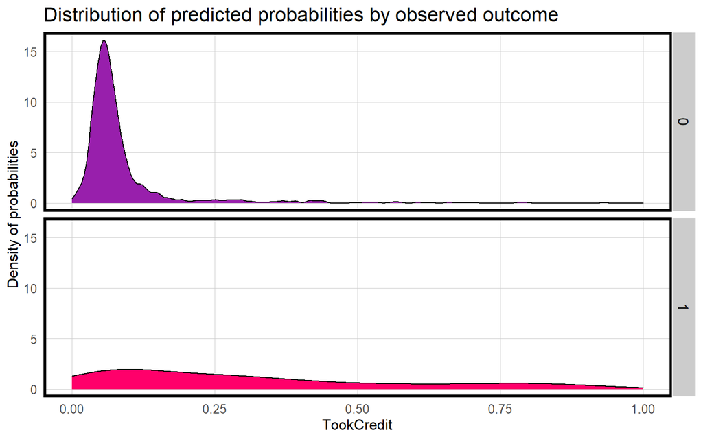

```r
 ggplot(testProbs, aes(x = Probs, fill = as.factor(Outcome))) +
  geom_density() +
  facet_grid(Outcome ~ .) +
  scale_fill_manual(values = palette2) + xlim(0, 1) +
  labs(x = "TookCredit", y = "Density of probabilities",
       title = "Distribution of predicted probabilities by observed outcome") +
  plotTheme() + theme(strip.text.x = element_text(size = 18),
        legend.position = "none")
```

The model does better at predicting “no” - homeowners that did not receive the credit vs. “yes” - the ones that took the credit.

## 0.4 Goodness of Fit

### 0.4.1 Confusion Matrix

The Confusion Matrix shows the number of observed instances of homeowners taking the credit, which is predicted as such. Each entry in the matrix provides a different comparison between observed and predicted, given the 50% threshold.

```r
testProbs <-
  testProbs %>%
  mutate(predOutcome  = as.factor(ifelse(testProbs$Probs > 0.5 , 1, 0)))

head(testProbs)
##    Outcome      Probs predOutcome
## 5        0 0.06629257           0
## 6        0 0.19519453           0
## 9        0 0.05152335           0
## 10       0 0.04855220           0
## 13       0 0.04870768           0
## 15       0 0.12193000           0
```

```
## Confusion Matrix and Statistics
##
##           Reference
## Prediction    0    1
##          0 1264  121
##          1   19   36
##
##                Accuracy : 0.9028
##                  95% CI : (0.8863, 0.9176)
##     No Information Rate : 0.891
##     P-Value [Acc > NIR] : 0.07982
##
##                   Kappa : 0.3
##
##  Mcnemar's Test P-Value : < 0.0000000000000002
##
##             Sensitivity : 0.22930
##             Specificity : 0.98519
##          Pos Pred Value : 0.65455
##          Neg Pred Value : 0.91264
##              Prevalence : 0.10903
##          Detection Rate : 0.02500
##    Detection Prevalence : 0.03819
##       Balanced Accuracy : 0.60725
##
##        'Positive' Class : 1
##
```

### 0.4.2 ROC Curves

The AUC curve for the engineered model is .80. Given that the AUC is between 0.5 and 1, the model is decent.

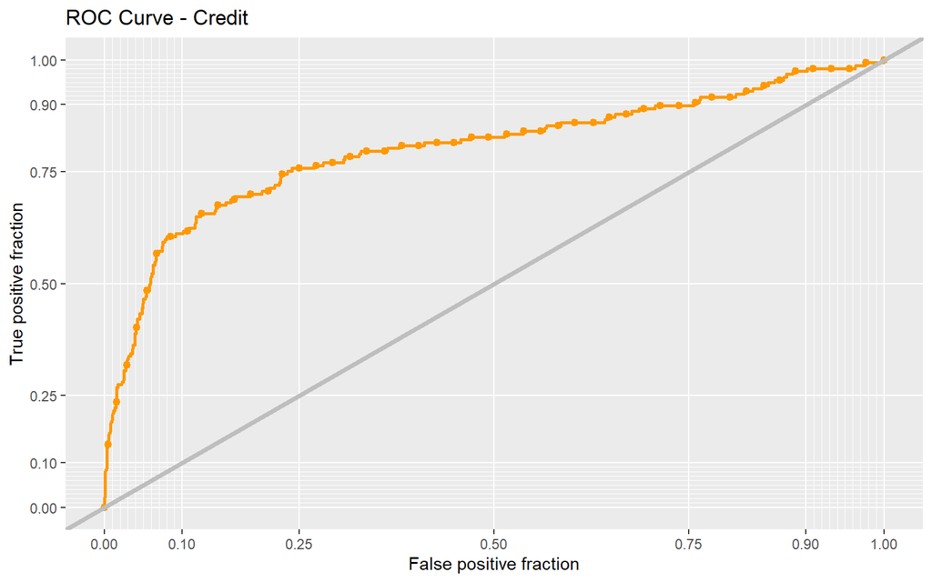

```
## Area under the curve: 0.8009
```

```r
ggplot(testProbs, aes(d = as.numeric(testProbs$Outcome), m = Probs)) +
  geom_roc(n.cuts = 50, labels = FALSE, colour = "#FE9900") +
  style_roc(theme = theme_grey) +
  geom_abline(slope = 1, intercept = 0, size = 1.5, color = 'grey') +
  labs(title = "ROC Curve - Credit")
```

### 0.4.3 Cross Validation

```r
ctrl <- trainControl(method = "cv", number = 100, classProbs=TRUE, summaryFunction=twoClassSummary)

cvFit_kichensink <- train(y ~ ., data = Housing  %>%
                                  na.omit() %>%
                                   dplyr::select(-y_numeric, -taxLien),
                method="glm", family="binomial",
                metric="ROC", trControl = ctrl)

cvFit_engineered <- train(y ~ ., data = Housing %>%
                                   dplyr::select(-y_numeric,-taxLien, -age, -month, -education, -job),
                method="glm", family="binomial",
                metric="ROC", trControl = ctrl)
cvFit_kichensink
## Generalized Linear Model
##
## 4119 samples
##   23 predictor
##    2 classes: 'no', 'yes'
##
## No pre-processing
## Resampling: Cross-Validated (100 fold)
## Summary of sample sizes: 4077, 4078, 4077, 4077, 4077, 4078, ...
## Resampling results:
##
##   ROC        Sens       Spec
##   0.7687414  0.9803378  0.2155
cvFit_engineered
## Generalized Linear Model
##
## 4119 samples
##   19 predictor
##    2 classes: 'no', 'yes'
##
## No pre-processing
## Resampling: Cross-Validated (100 fold)
## Summary of sample sizes: 4077, 4077, 4077, 4077, 4079, 4077, ...
## Resampling results:
##
##   ROC        Sens       Spec
##   0.7654396  0.9844595  0.217
```

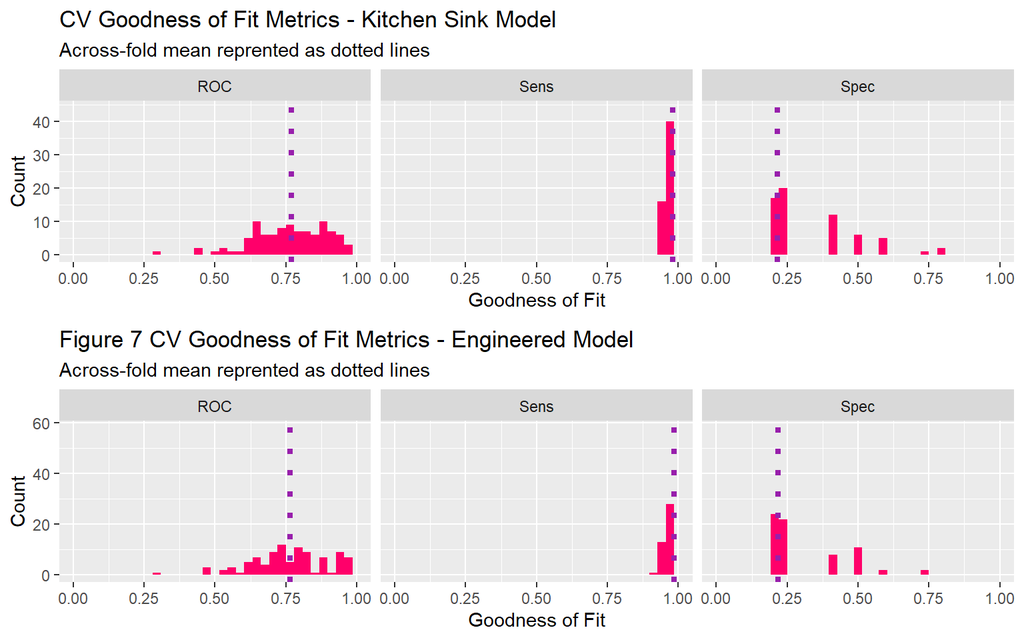

```r
grid.arrange(ncol = 1,
  dplyr::select(cvFit_kichensink$resample, -Resample) %>%
  gather(metric, value) %>%
  left_join(gather(cvFit_kichensink$results[2:4], metric, mean)) %>%
  ggplot(aes(value)) +
  geom_histogram(bins=35, fill = "#FF006A") +
  facet_wrap(~metric) +
  geom_vline(aes(xintercept = mean), colour = "#981FAC", linetype = 3, size = 1.5) +
  scale_x_continuous(limits = c(0, 1)) +
  labs(x="Goodness of Fit", y="Count", title="CV Goodness of Fit Metrics - Kitchen Sink Model",
       subtitle = "Across-fold mean reprented as dotted lines"),

  dplyr::select(cvFit_engineered$resample, -Resample) %>%
  gather(metric, value) %>%
  left_join(gather(cvFit_engineered$results[2:4], metric, mean)) %>%
  ggplot(aes(value)) +
  geom_histogram(bins=35, fill = "#FF006A") +
  facet_wrap(~metric) +
  geom_vline(aes(xintercept = mean), colour = "#981FAC", linetype = 3, size = 1.5) +
  scale_x_continuous(limits = c(0, 1)) +
  labs(x="Goodness of Fit", y="Count", title="Figure 7 CV Goodness of Fit Metrics - Engineered Model",
       subtitle = "Across-fold mean reprented as dotted lines"))
## Joining, by = "metric"
## Joining, by = "metric"
```

## 0.5 Cost/Benefit Analysis

The cost/benefit analysis was developed with the following parameters:

- Marketing Costs: $2,850
- Credit allocated per household: $5,000.
- 25% of eligible homeowners receive credit

Below the cost/benefit for each outcome in our confusion matrix is calculated:

```r
cost_benefit_table <-
   testProbs %>%
      count(predOutcome, Outcome) %>%
      summarize(True_Negative = sum(n[predOutcome==0 & Outcome==0]),
                True_Positive = sum(n[predOutcome==1 & Outcome==1]),
                False_Negative = sum(n[predOutcome==0 & Outcome==1]),
                False_Positive = sum(n[predOutcome==1 & Outcome==0])) %>%
       gather(Variable, Count) %>%
       mutate(Revenue =
               case_when(Variable == "True_Negative"  ~ Count * 0,
                         Variable == "True_Positive"  ~ (Count * -2850) - ((Count * .25) * -5000),
                         Variable == "False_Negative" ~ (0) * Count,
                         Variable == "False_Positive" ~ (- 2850) * Count)) %>%
    bind_cols(data.frame(Description = c(
              "Predicted HO would not take the credit, no marketing, and no credit was allocated",
              "Predicted HO would enter credit program and allocated the marketing resources, and 25% took the credit",
              "Predicted HO would not take the credit but they did",
              "Predicted that HO would take the credit, allocated marketing resources, no credit allocated")))

kable(cost_benefit_table,
       caption = "Cost/Benefit Table") %>% kable_styling()
```

Cost/Benefit Table

| Variable | Count | Revenue | Description |
| --- | --- | --- | --- |
| True_Negative | 1264 | 0 | Predicted HO would not take the credit, no marketing, and no credit was allocated |
| True_Positive | 36 | -57600 | Predicted HO would enter credit program and allocated the marketing resources, and 25% took the credit |
| False_Negative | 121 | 0 | Predicted HO would not take the credit but they did |
| False_Positive | 19 | -54150 | Predicted that HO would take the credit, allocated marketing resources, no credit allocated |

Regarding this program, the revenue of $0 is positive because the departments spend less on outreach and saves money. However, only 25% of the homeowners ultimately receive the credit, and the department loses a lot of money from the marketing efforts allotted to the other 75% of eligible homeowners (true positive). False positives also cost the department a lot of money.

```r
whichThreshold <-
  iterateThresholds(
     data=testProbs, observedClass = Outcome, predictedProbs = Probs)

whichThreshold[1:5,]
## # A tibble: 5 × 10
##   Count_TN Count_TP Count_FN Count_FP Rate_TP Rate_FP Rate_FN Rate_TN Accuracy
##      <int>    <int>    <int>    <int>   <dbl>   <dbl>   <dbl>   <dbl>    <dbl>
## 1        9      156        1     1274   0.994   0.993 0.00637 0.00701    0.115
## 2       36      155        2     1247   0.987   0.972 0.0127  0.0281     0.133
## 3       73      154        3     1210   0.981   0.943 0.0191  0.0569     0.158
## 4      191      148        9     1092   0.943   0.851 0.0573  0.149      0.235
## 5      379      140       17      904   0.892   0.705 0.108   0.295      0.360
## # … with 1 more variable: Threshold <dbl>


whichThreshold <-
  whichThreshold %>%
    dplyr::select(starts_with("Count"), Threshold) %>%
    gather(Variable, Count, -Threshold) %>%
    mutate(Revenue =
             case_when(Variable == "Count_TN"  ~  Count * 0,
                       Variable == "Count_TP"  ~ (Count * -2850) - ((Count * .25) * -5000),
                       Variable == "Count_FN"  ~ (0) * Count,
                       Variable == "Count_FP"  ~  (- 2850) * Count))
```

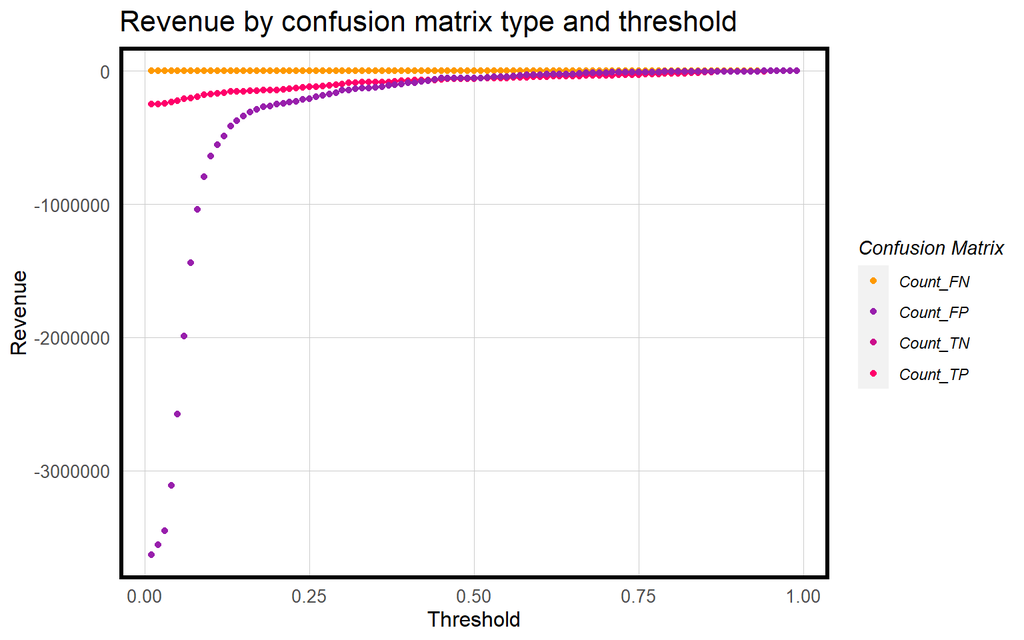

```r
whichThreshold %>%
  ggplot(.,aes(Threshold, Revenue, colour = Variable)) +
  geom_point() +
  scale_colour_manual(values = palette5[c(5, 1:3)]) +
  labs(title = "Revenue by confusion matrix type and threshold",
       y = "Revenue") +
  plotTheme() +
  guides(colour=guide_legend(title = "Confusion Matrix"))
```

The revenue starts to flatten out to $0 at a threshold of 0.5. To minimize costs, the threshold should be set between 0.5 to 1.

```r
whichThreshold_revenue <-
  whichThreshold %>%
    mutate(tookCredit = ifelse(Variable == "Count_TP", (Count * .5),
                         ifelse(Variable == "Count_FN", Count, 0))) %>%
    group_by(Threshold) %>%
    summarize(Total_Revenue = sum(Revenue),
              Total_Count_of_Credit = sum(tookCredit))
```

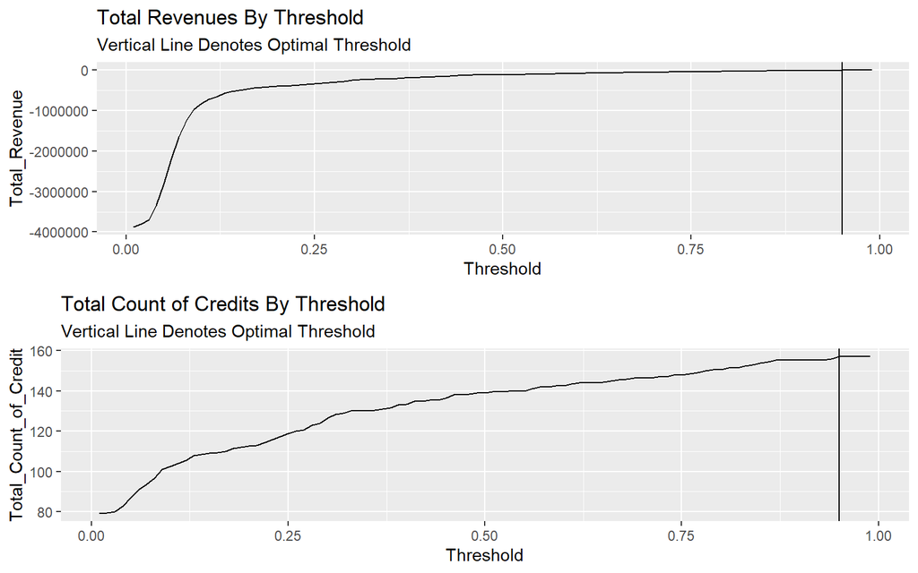

```r
# Revenue
grid.arrange(ncol = 1,
ggplot(whichThreshold_revenue)+
  geom_line(aes(x = Threshold, y = Total_Revenue))+
  geom_vline(xintercept =  pull(arrange(whichThreshold_revenue, -Total_Revenue)[1,1]))+
    labs(title = "Total Revenues By Threshold",
         subtitle = "Vertical Line Denotes Optimal Threshold"),
# Credits
ggplot(whichThreshold_revenue)+
  geom_line(aes(x = Threshold, y = Total_Count_of_Credit))+
  geom_vline(xintercept =  pull(arrange(whichThreshold_revenue, -Total_Count_of_Credit)[1,1]))+
    labs(title = "Total Count of Credits By Threshold",
         subtitle = "Vertical Line Denotes Optimal Threshold"))
```

The optimal threshold to maximize the revenue is .95

```r
optimalthreshold <-
  whichThreshold_revenue

optimalthreshold_table <-
  whichThreshold_revenue


t1 <- filter(optimalthreshold_table,Threshold == 0.50)
t2 <- filter(optimalthreshold_table,Threshold == 0.95)

t <- rbind(t1,t2)

kable(t, caption = "Cost/Benefit Table") %>% kable_styling()
```

Cost/Benefit Table

| Threshold | Total_Revenue | Total_Count_of_Credit |
| --- | --- | --- |
| 0.50 | -111750 | 139 |
| 0.95 | 0 | 157 |

## 0.6 Conclusion

In this analysis, adding engineered features to the dataset did not necessarily yield better results than expected. Further analysis of the data should be carried out to engineer better features that may significantly impact the model. Using the optimal threshold of 95% ensures that the least amount of money is spent or “wasted”. However, since the goal is to increase the number of homeowners who would benefit from this program, it is further measures need to be taken to improve the response rate.

The marketing campaign needs to adjust according to the patterns identified in the data. For example, cell phones were the most effective form of contact for marketing initiatives. Married households were most likely to enroll in the program and the summer months had the highest amounts of enrollment in the tax credit.